# Pivoting data

When manipulating data, *pivoting* can be understood to refer to one of two processes:

1. the creation of *pivot tables*, which are tables “… of statistics that summarize the data of a more extensive table (such as from a database, spreadsheet, or business intelligence program). This summary might include sums, averages, or other statistics, which the pivot table groups together in a meaningful way… They arrange and rearrange (or”pivot“) statistics in order to draw attention to useful information. This leads to finding figures and facts quickly making them integral to data analysis.” see [wiki](https://en.wikipedia.org/wiki/Pivot_table#).
2. The conversion of a table from **long** to **wide** format, or vice versa.

**In this page, we will focus on the latter definition.** The former is a crucial step in data analysis, and is covered elsewhere in the [Grouping data] and [Descriptive tables] pages.

## Preparation

### Load packages

This code chunk shows the loading of packages required for the analyses. In this handbook we emphasize `p_load()` from **pacman**, which installs the package if necessary and loads it for use. You can also load installed packages with `library()` from **base** R. See the page on [R basics] for more information on R packages.

```r
pacman::p_load(
  rio,          # File import
  here,         # File locator
  tidyverse)    # data management + ggplot2 graphics
```

### Import data

We import the dataset of cases from a simulated Ebola epidemic. If you want to download the data to follow step-by-step, see instructions in the [Download book and data] page. The dataset is imported using the `import()` function from the **rio** package. See the page on [Import and export] for various ways to import data.

```r
# import the linelist
linelist <- import("linelist_cleaned.xlsx")
```

The first 50 rows of the linelist are displayed below.

| case_id | generation | date_infection | date_onset | date_hospitalisation | date_outcome | outcome | gender | age | age_unit | age_years | age_cat | age_cat5 | hospital | lon | lat | infector | source | wt_kg | ht_cm | ct_blood | fever | chills | cough | aches | vomit | temp | time_admission | bmi | days_onset_hosp |
| --- | --- | --- | --- | --- | --- | --- | --- | --- | --- | --- | --- | --- | --- | --- | --- | --- | --- | --- | --- | --- | --- | --- | --- | --- | --- | --- | --- | --- | --- |
| 5fe599 | 4 | 2014-05-08 | 2014-05-13 | 2014-05-15 |  |  | m | 2 | years | 2 | 0-4 | 0-4 | Other | -13.2157351064963 | 8.46897295100924 | f547d6 | other | 27 | 48 | 22 | no | no | yes | no | yes | 36.8 |  | 117.1875 | 2 |
| 8689b7 | 4 |  | 2014-05-13 | 2014-05-14 | 2014-05-18 | Recover | f | 3 | years | 3 | 0-4 | 0-4 | Missing | -13.2152339775486 | 8.45171855856465 |  |  | 25 | 59 | 22 |  |  |  |  |  | 36.9 | 09:36 | 71.8184429761563 | 1 |
| 11f8ea | 2 |  | 2014-05-16 | 2014-05-18 | 2014-05-30 | Recover | m | 56 | years | 56 | 50-69 | 55-59 | St. Mark's Maternity Hospital (SMMH) | -13.212910703914 | 8.46481700596819 |  |  | 91 | 238 | 21 |  |  |  |  |  | 36.9 | 16:48 | 16.0652496292635 | 2 |
| b8812a | 3 | 2014-05-04 | 2014-05-18 | 2014-05-20 |  |  | f | 18 | years | 18 | 15-19 | 15-19 | Port Hospital | -13.2363711169728 | 8.4754761613651 | f90f5f | other | 41 | 135 | 23 | no | no | no | no | no | 36.8 | 11:22 | 22.4965706447188 | 2 |
| 893f25 | 3 | 2014-05-18 | 2014-05-21 | 2014-05-22 | 2014-05-29 | Recover | m | 3 | years | 3 | 0-4 | 0-4 | Military Hospital | -13.2228638912441 | 8.46082377490923 | 11f8ea | other | 36 | 71 | 23 | no | no | yes | no | yes | 36.9 | 12:60 | 71.4144019043841 | 1 |
| be99c8 | 3 | 2014-05-03 | 2014-05-22 | 2014-05-23 | 2014-05-24 | Recover | f | 16 | years | 16 | 15-19 | 15-19 | Port Hospital | -13.222625321098 | 8.46183062600728 | aec8ec | other | 56 | 116 | 21 | no | no | yes | no | yes | 37.6 | 14:13 | 41.6171224732461 | 1 |
| 07e3e8 | 4 | 2014-05-22 | 2014-05-27 | 2014-05-29 | 2014-06-01 | Recover | f | 16 | years | 16 | 15-19 | 15-19 | Missing | -13.2331547837254 | 8.46272931462646 | 893f25 | other | 47 | 87 | 21 |  |  |  |  |  | 37.3 | 14:33 | 62.0953890870657 | 2 |
| 369449 | 4 | 2014-05-28 | 2014-06-02 | 2014-06-03 | 2014-06-07 | Death | f | 0 | years | 0 | 0-4 | 0-4 | Missing | -13.2320975453153 | 8.46144367534271 | 133ee7 | other | 0 | 11 | 22 | no | no | yes | no | yes | 37 | 09:25 | 0 | 1 |
| f393b4 | 4 |  | 2014-06-05 | 2014-06-06 | 2014-06-18 | Recover | m | 61 | years | 61 | 50-69 | 60-64 | Missing | -13.2225511595637 | 8.46191259217774 |  |  | 86 | 226 | 22 | no | no | yes | no | yes | 36.4 | 11:16 | 16.8376536925366 | 1 |
| 1389ca | 4 |  | 2014-06-05 | 2014-06-07 | 2014-06-09 | Death | f | 27 | years | 27 | 20-29 | 25-29 | Missing | -13.2572163655863 | 8.47292327643506 |  |  | 69 | 174 | 22 | no | no | yes | no | no | 35.9 | 10:55 | 22.7903289734443 | 2 |

[output cut: 40 more lines]

## Wide-to-long

Transforming a dataset from wide to long ([image source](https://d33wubrfki0l68.cloudfront.net/3aea19108d39606bbe49981acda07696c0c7fcd8/2de65/images/tidy-9.png))

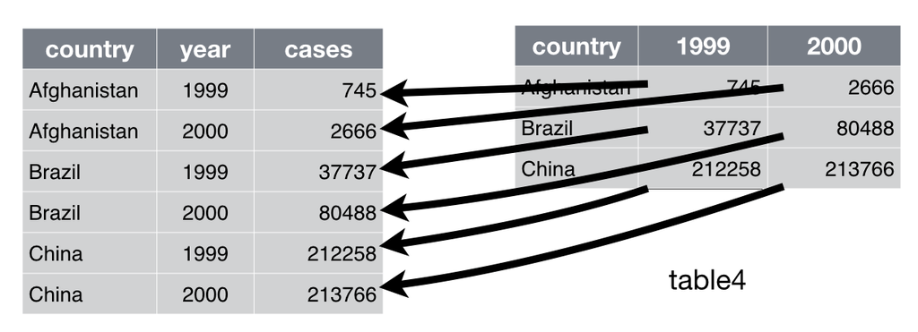

### Data

Data are often entered and stored in a format that might be useful for presentation, but not for analysis. Let us take the `count_data` dataset as an example, which is stored in a “wide” format, which means that each column is a variable and each row an observation. This is useful for presenting the information in a table or for entering data (e.g. in Excel) from case report forms. However, these typically needs to be transformed to “long” format in order to analyse and visualise.

```r
count_data <- import("facility_count_data.rds")
```

| location_name | data_date | submitted_date | Province | District | malaria_rdt_0-4 | malaria_rdt_5-14 | malaria_rdt_15 | malaria_tot | newid |
| --- | --- | --- | --- | --- | --- | --- | --- | --- | --- |
| Facility 1 | 2019-06-13 | 2019-06-14 | North | Spring | 11 | 12 | 23 | 46 | 1 |
| Facility 2 | 2019-06-13 | 2019-06-14 | North | Bolo | 11 | 10 | 5 | 26 | 2 |
| Facility 3 | 2019-06-13 | 2019-06-14 | North | Dingo | 8 | 5 | 5 | 18 | 3 |
| Facility 4 | 2019-06-13 | 2019-06-14 | North | Bolo | 16 | 16 | 17 | 49 | 4 |
| Facility 5 | 2019-06-13 | 2019-06-14 | North | Bolo | 9 | 2 | 6 | 17 | 5 |
| Facility 6 | 2019-06-13 | 2019-06-14 | North | Dingo | 3 | 1 | 4 | 8 | 6 |
| Facility 6 | 2019-06-12 | 2019-06-14 | North | Dingo | 4 | 0 | 3 | 7 | 6 |
| Facility 5 | 2019-06-12 | 2019-06-14 | North | Bolo | 15 | 14 | 13 | 42 | 5 |
| Facility 5 | 2019-06-11 | 2019-06-14 | North | Bolo | 11 | 11 | 13 | 35 | 5 |
| Facility 5 | 2019-06-10 | 2019-06-14 | North | Bolo | 19 | 15 | 15 | 49 | 5 |

[output cut: 3028 more lines]

Each observation in this dataset refers to the malaria counts at one of 65 facilities on a given date, ranging from 2019-03-18 to 2019-06-14. These facilties are located in one `Province` (North) and four `District`s (Spring, Bolo, Dingo, and Barnard). The dataset provides the overall counts of malaria, as well as age-specific counts in each of three age groups - <4 years, 5-14 years, and 15 years and older.

Visualising the overall malaria counts over time poses no difficulty with the data in it’s current format:

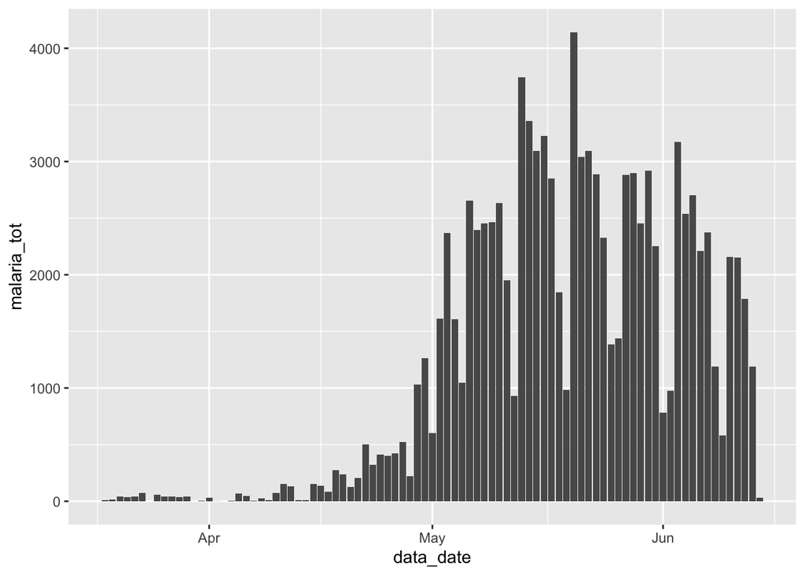

```r
ggplot(count_data) +
  geom_col(aes(x = data_date, y = malaria_tot))
```

However, what if we wanted to display the relative contributions of each age group to this total count? In this case, we need to ensure that the variable of interest (age group), appears in the dataset in a single column that can be passed to `{ggplot2}`’s “aesthetics” (`aes()`) function.

### `pivot_longer()`

#### Pivotting single columns

First, let’s begin by loading our packages and converting `count_data` to a tibble for easy printing:

```r
pacman::p_load(tidyverse)

# Convert count_data to `tibble` for better printing
count_data <-
  count_data %>%
  as_tibble()

count_data
```

```
## # A tibble: 3,038 x 10
##    location_name data_date  submitted_date Province District `malaria_rdt_0-4`
##    <chr>         <date>     <date>         <chr>    <chr>                <int>
##  1 Facility 1    2019-06-13 2019-06-14     North    Spring                  11
##  2 Facility 2    2019-06-13 2019-06-14     North    Bolo                    11
##  3 Facility 3    2019-06-13 2019-06-14     North    Dingo                    8
##  4 Facility 4    2019-06-13 2019-06-14     North    Bolo                    16
##  5 Facility 5    2019-06-13 2019-06-14     North    Bolo                     9
##  6 Facility 6    2019-06-13 2019-06-14     North    Dingo                    3
##  7 Facility 6    2019-06-12 2019-06-14     North    Dingo                    4
##  8 Facility 5    2019-06-12 2019-06-14     North    Bolo                    15
##  9 Facility 5    2019-06-11 2019-06-14     North    Bolo                    11
## 10 Facility 5    2019-06-10 2019-06-14     North    Bolo                    19
## # … with 3,028 more rows, and 4 more variables: malaria_rdt_5-14 <int>,
## #   malaria_rdt_15 <int>, malaria_tot <int>, newid <int>
```

Next, we want to use `{tidyr}`’s `pivot_longer()` function to convert the wide dataset to a long format, converting the four columns with data on malaria counts to two new columns: one which captures the variable *name* and one which captures the *values* from the cells. Since these four variables all begin with the prefix `malaria_`, we can make use of the handy function `starts_with()`.

```r
df_long <-
  count_data %>%
  pivot_longer(
    cols = starts_with("malaria_")
  )

df_long
```

```
## # A tibble: 12,152 x 8
##    location_name data_date  submitted_date Province District newid name    value
##    <chr>         <date>     <date>         <chr>    <chr>    <int> <chr>   <int>
##  1 Facility 1    2019-06-13 2019-06-14     North    Spring       1 malari…    11
##  2 Facility 1    2019-06-13 2019-06-14     North    Spring       1 malari…    12
##  3 Facility 1    2019-06-13 2019-06-14     North    Spring       1 malari…    23
##  4 Facility 1    2019-06-13 2019-06-14     North    Spring       1 malari…    46
##  5 Facility 2    2019-06-13 2019-06-14     North    Bolo         2 malari…    11
##  6 Facility 2    2019-06-13 2019-06-14     North    Bolo         2 malari…    10
##  7 Facility 2    2019-06-13 2019-06-14     North    Bolo         2 malari…     5
##  8 Facility 2    2019-06-13 2019-06-14     North    Bolo         2 malari…    26
##  9 Facility 3    2019-06-13 2019-06-14     North    Dingo        3 malari…     8
## 10 Facility 3    2019-06-13 2019-06-14     North    Dingo        3 malari…     5
## # … with 12,142 more rows
```

However, we could also have specified the columns by position:

```r
count_data %>%
  pivot_longer(
    cols = 6:9
  )
```

```
## # A tibble: 12,152 x 8
##    location_name data_date  submitted_date Province District newid name    value
##    <chr>         <date>     <date>         <chr>    <chr>    <int> <chr>   <int>
##  1 Facility 1    2019-06-13 2019-06-14     North    Spring       1 malari…    11
##  2 Facility 1    2019-06-13 2019-06-14     North    Spring       1 malari…    12
##  3 Facility 1    2019-06-13 2019-06-14     North    Spring       1 malari…    23
##  4 Facility 1    2019-06-13 2019-06-14     North    Spring       1 malari…    46
##  5 Facility 2    2019-06-13 2019-06-14     North    Bolo         2 malari…    11
##  6 Facility 2    2019-06-13 2019-06-14     North    Bolo         2 malari…    10
##  7 Facility 2    2019-06-13 2019-06-14     North    Bolo         2 malari…     5
##  8 Facility 2    2019-06-13 2019-06-14     North    Bolo         2 malari…    26
##  9 Facility 3    2019-06-13 2019-06-14     North    Dingo        3 malari…     8
## 10 Facility 3    2019-06-13 2019-06-14     North    Dingo        3 malari…     5
## # … with 12,142 more rows
```

or by named range:

```r
count_data %>%
  pivot_longer(
    cols = `malaria_rdt_0-4`:malaria_tot
  )
```

```
## # A tibble: 12,152 x 8
##    location_name data_date  submitted_date Province District newid name    value
##    <chr>         <date>     <date>         <chr>    <chr>    <int> <chr>   <int>
##  1 Facility 1    2019-06-13 2019-06-14     North    Spring       1 malari…    11
##  2 Facility 1    2019-06-13 2019-06-14     North    Spring       1 malari…    12
##  3 Facility 1    2019-06-13 2019-06-14     North    Spring       1 malari…    23
##  4 Facility 1    2019-06-13 2019-06-14     North    Spring       1 malari…    46
##  5 Facility 2    2019-06-13 2019-06-14     North    Bolo         2 malari…    11
##  6 Facility 2    2019-06-13 2019-06-14     North    Bolo         2 malari…    10
##  7 Facility 2    2019-06-13 2019-06-14     North    Bolo         2 malari…     5
##  8 Facility 2    2019-06-13 2019-06-14     North    Bolo         2 malari…    26
##  9 Facility 3    2019-06-13 2019-06-14     North    Dingo        3 malari…     8
## 10 Facility 3    2019-06-13 2019-06-14     North    Dingo        3 malari…     5
## # … with 12,142 more rows
```

Notice that the newly created dataframe (`df_long`) has more rows (12,152 vs 3,038); it has become *longer*. In fact, it is precisely four times as long, because each row in the original dataset now represents four rows in df_long, one for each of the malaria count observations (<4y, 5-14y, 15y+, and total).

In addition to becoming longer, the new dataset has fewer columns (8 vs 10), as the data previously stored in four columns (those beginning with the prefix `malaria_`) is now stored in two. These two columns are given the default names of `name` and `value`, but we can override these defaults to provide more meaningful names, which can help remember what is stored within, using the `names_to` and `values_to` arguments. Let’s use the names `age_group` and `counts`:

```r
df_long <-
  count_data %>%
  pivot_longer(
    cols = starts_with("malaria_"),
    names_to = "age_group",
    values_to = "counts"
  )

df_long
```

```
## # A tibble: 12,152 x 8
##    location_name data_date  submitted_date Province District newid age_group
##    <chr>         <date>     <date>         <chr>    <chr>    <int> <chr>
##  1 Facility 1    2019-06-13 2019-06-14     North    Spring       1 malaria_rdt_…
##  2 Facility 1    2019-06-13 2019-06-14     North    Spring       1 malaria_rdt_…
##  3 Facility 1    2019-06-13 2019-06-14     North    Spring       1 malaria_rdt_…
##  4 Facility 1    2019-06-13 2019-06-14     North    Spring       1 malaria_tot
##  5 Facility 2    2019-06-13 2019-06-14     North    Bolo         2 malaria_rdt_…
##  6 Facility 2    2019-06-13 2019-06-14     North    Bolo         2 malaria_rdt_…
##  7 Facility 2    2019-06-13 2019-06-14     North    Bolo         2 malaria_rdt_…
##  8 Facility 2    2019-06-13 2019-06-14     North    Bolo         2 malaria_tot
##  9 Facility 3    2019-06-13 2019-06-14     North    Dingo        3 malaria_rdt_…
## 10 Facility 3    2019-06-13 2019-06-14     North    Dingo        3 malaria_rdt_…
## # … with 12,142 more rows, and 1 more variable: counts <int>
```

We can now pass this new dataset to `{ggplot2}` to display the malaria counts by age group:

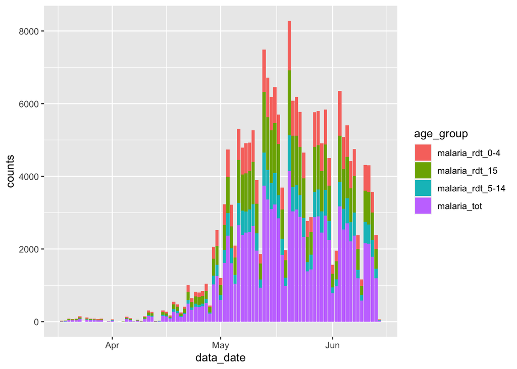

```r
ggplot(df_long) +
  geom_col(
    aes(x = data_date, y = counts, fill = age_group)
  )
```

Examine this new plot, and compare it with the plot we created earlier - what has gone wrong? We have encountered a common problem when wrangling surveillance data - we have also included the total counts from the `malaria_tot` column, so the magnitude of each bar in the plot is twice as high as it should be.

We can handle this in a number of ways. We could simply filter it from the dataset we pass to `{ggplot2}`:

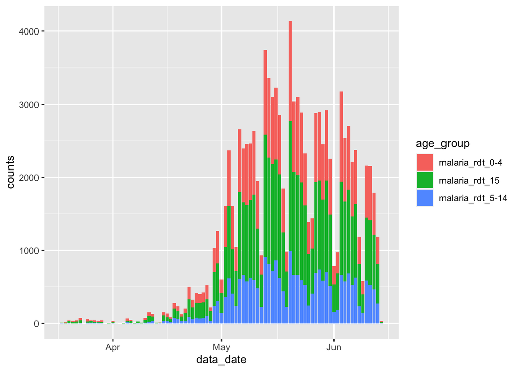

```r
df_long %>%
  filter(age_group != "malaria_tot") %>%
  ggplot() +
  geom_col(
    aes(x = data_date, y = counts, fill = age_group)
  )
```

Alternatively, we could have excluded this variable when we ran `pivot_longer()`, thereby maintaining it in the dataset as a separate variable:

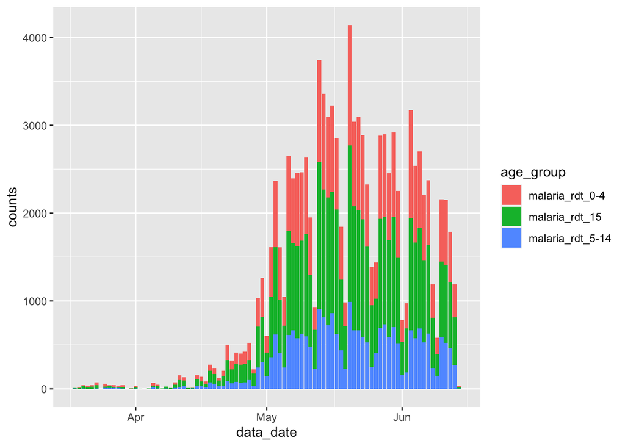

```r
count_data %>%
  pivot_longer(
    cols = `malaria_rdt_0-4`:malaria_rdt_15,
    names_to = "age_group",
    values_to = "counts"
  ) %>%
  ggplot() +
  geom_col(
    aes(x = data_date, y = counts, fill = age_group)
  )
```

#### Pivotting multiple columns

The above example works well in situations in which good (*tidy*) data management principles have been adhered to. However, there will be many cases when, as a field epidemiologist, you will be working with data that was prepared by non-specialists and which follow their own non-standard logic - as Hadley Wickham noted (referencing Tolstoy) in his [seminal article](https://vita.had.co.nz/papers/tidy-data.pdf) on **Tidy Data** principles: “Like families, tidy datasets are all alike but every messy dataset is messy in its own way.”

One particularly common problem you will encounter will be the storing of different data types in a single column. There are various approaches one can take to separate out the mess this creates, but there is an important step you can take using `pivot_longer()` to avoid creating such a situation yourself.

Take a situation in which there have been a series of observations at different time steps for each of three items A, B and C. Examples of such items could be individuals (e.g. contacts of an Ebola case being traced each day for 21 days) or remote village health posts being monitored once per year to ensure they are still functional. Let’s use the contact tracing example. Imagine that the dataare stored as follows:

| id | obs1_date | obs1_status | obs2_date | obs2_status | obs3_date | obs3_status |
| --- | --- | --- | --- | --- | --- | --- |
| A | 2021-04-23 | Healthy | 2021-04-24 | Healthy | 2021-04-25 | Unwell |
| B | 2021-04-23 | Healthy | 2021-04-24 | Healthy | 2021-04-25 | Healthy |
| C | 2021-04-23 | Missing | 2021-04-24 | Healthy | 2021-04-25 | Healthy |

As can be seen, the data are a bit messy, with each row referring to one item, but the time series running further and further away to the right as time progresses. One particularly bad example of this encountered by this author involved cholera surveillance data, in which 8 new columns of observations were added *each day* over the course of **4 years**. Simply opening the Excel file in which these data were stored took >10 mins on my laptop!

In order to work with these data, we need to transform the dataframe to long format, but keeping the separation between a `date` column and a `character` (status) column, for each observation for each item. If we don’t, we might end up with a mixture of variable types in a single column (a very big no-no when it comes to data management and tidy data):

```r
df %>%
  pivot_longer(
    cols = -id,
    names_to = c("observation")
  )
```

```
## # A tibble: 18 x 3
##    id    observation value
##    <chr> <chr>       <chr>
##  1 A     obs1_date   2021-04-23
##  2 A     obs1_status Healthy
##  3 A     obs2_date   2021-04-24
##  4 A     obs2_status Healthy
##  5 A     obs3_date   2021-04-25
##  6 A     obs3_status Unwell
##  7 B     obs1_date   2021-04-23
##  8 B     obs1_status Healthy
##  9 B     obs2_date   2021-04-24
## 10 B     obs2_status Healthy
## 11 B     obs3_date   2021-04-25
## 12 B     obs3_status Healthy
## 13 C     obs1_date   2021-04-23
## 14 C     obs1_status Missing
## 15 C     obs2_date   2021-04-24
## 16 C     obs2_status Healthy
## 17 C     obs3_date   2021-04-25
## 18 C     obs3_status Healthy
```

Here we have merged dates and characters into a single `value` column.

We can keep these data types separated by specifying a second condition (`".value"` ) to the `names_to` argument, combined with the `names_sep` argument where we specify that the naming and split of new columns is based around the underscore in the existing variable names:

```r
df_long <-
  df %>%
  pivot_longer(
    cols = -id,
    names_to = c("observation", ".value"),
    names_sep = "_"
  )

df_long
```

```
## # A tibble: 9 x 4
##   id    observation date       status
##   <chr> <chr>       <chr>      <chr>
## 1 A     obs1        2021-04-23 Healthy
## 2 A     obs2        2021-04-24 Healthy
## 3 A     obs3        2021-04-25 Unwell
## 4 B     obs1        2021-04-23 Healthy
## 5 B     obs2        2021-04-24 Healthy
## 6 B     obs3        2021-04-25 Healthy
## 7 C     obs1        2021-04-23 Missing
## 8 C     obs2        2021-04-24 Healthy
## 9 C     obs3        2021-04-25 Healthy
```

**Finishing touches**:

Note that the `date` column is currently in character format - we can easily convert this into it’s proper `date` format using the `mutate()` function encountered elsewhere. We may also want to convert the `observation` column to a `numeric` format by dropping the `obs` prefix and converting to `numeric`:

```r
df_long <-
  df_long %>%
  mutate(
    date =
      date %>% lubridate::as_date(),
    observation =
      observation %>%
      str_remove_all("obs") %>%
      as.numeric()
  )

df_long
```

```
## # A tibble: 9 x 4
##   id    observation date       status
##   <chr>       <dbl> <date>     <chr>
## 1 A               1 2021-04-23 Healthy
## 2 A               2 2021-04-24 Healthy
## 3 A               3 2021-04-25 Unwell
## 4 B               1 2021-04-23 Healthy
## 5 B               2 2021-04-24 Healthy
## 6 B               3 2021-04-25 Healthy
## 7 C               1 2021-04-23 Missing
## 8 C               2 2021-04-24 Healthy
## 9 C               3 2021-04-25 Healthy
```

And now, we can start to work with the data in this format, e.g. by plotting

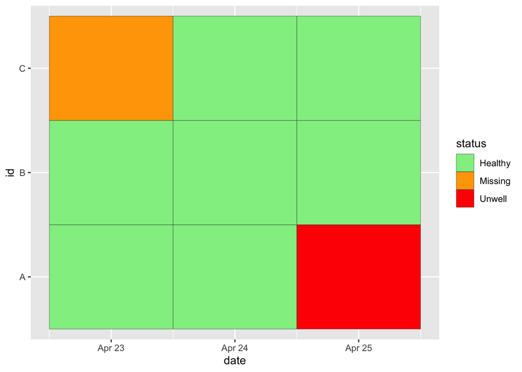

```r
ggplot(df_long) +
  aes(x = date, y = id, fill = status) +
  geom_tile(colour = "black") +
  scale_fill_manual(
    values =
      c(
        "Healthy" = "lightgreen",
        "Unwell" = "red",
        "Missing" = "orange"
      )
  )
```

## Long-to-wide

Transforming a dataset from long to wide ([image source](https://d33wubrfki0l68.cloudfront.net/8350f0dda414629b9d6c354f87acf5c5f722be43/bcb84/images/tidy-8.png))

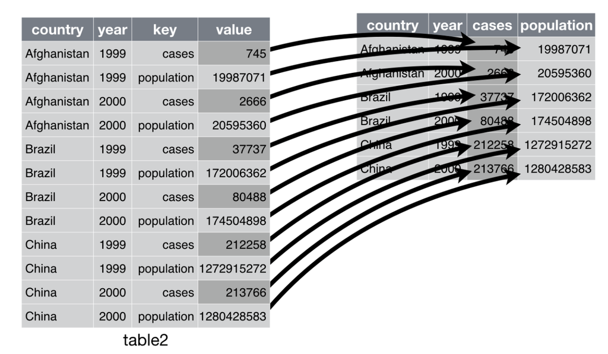

In some instances, we may wish to convert a dataset to a wider format. For this, we can use the `pivot_wider()` function.

A typical use case is when we want to transform the results of an analysis into a format which is more digestible for the reader. Usually, we are transforming a dataset in which the observations are spread over multiple rows to one in which each observation occupies a single row.

This introduces the useful topic of “tidy data”, in which each variable has it’s own column, each observation has it’s own row, and each value has it’s own cell. More about this topic can be found here https://r4ds.had.co.nz/tidy-data.html.

### Data

Let us use the `linelist` dataset. Suppose that we want to know the counts of individuals in the different age groups, by sex:

```r
linelist <-
  linelist %>%
  as_tibble()

df_wide <-
  linelist %>%
  count(age_cat, gender)

df_wide
```

```
## # A tibble: 24 x 3
##    age_cat gender     n
##    <fct>   <chr>  <int>
##  1 0-4     f        640
##  2 0-4     m        416
##  3 0-4     <NA>      39
##  4 5-9     f        641
##  5 5-9     m        412
##  6 5-9     <NA>      42
##  7 10-14   f        518
##  8 10-14   m        383
##  9 10-14   <NA>      40
## 10 15-19   f        359
## # … with 14 more rows
```

This gives us a long dataset that is great for producing visualisations in `ggplot2`, but not ideal for presentation in a table:

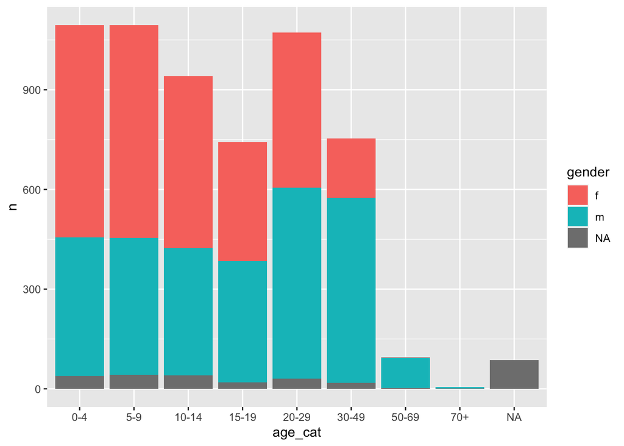

```r
ggplot(df_wide) +
  geom_col(aes(x = age_cat, y = n, fill = gender))
```

### Pivot wider

Therefore, we can use `pivot_wider()` to transform the data into a better format for inclusion as tables in our reports. The argument `names_from` specifies the column *from* which to generate the new column *names*, while the argument `values_from` specifies the column *from* which to take the *values* to populate the cells:

```r
table_wide <-
  df_wide %>%
  pivot_wider(
    names_from = gender,
    values_from = n
  )

table_wide
```

```
## # A tibble: 9 x 4
##   age_cat     f     m  `NA`
##   <fct>   <int> <int> <int>
## 1 0-4       640   416    39
## 2 5-9       641   412    42
## 3 10-14     518   383    40
## 4 15-19     359   364    20
## 5 20-29     468   575    30
## 6 30-49     179   557    18
## 7 50-69       2    91     2
## 8 70+        NA     5     1
## 9 <NA>       NA    NA    86
```

This table is much more reader-friendly, and therefore better for inclusion in our reports:

```r
table_wide %>%
  janitor::adorn_totals(c("row", "col")) %>% # adds row and column totals
  knitr::kable() %>%
  kableExtra::row_spec(row = 10, bold = TRUE) %>%
  kableExtra::column_spec(column = 5, bold = TRUE)
```

| age_cat | f | m | NA | Total |
| --- | --- | --- | --- | --- |
| 0-4 | 640 | 416 | 39 | 1095 |
| 5-9 | 641 | 412 | 42 | 1095 |
| 10-14 | 518 | 383 | 40 | 941 |
| 15-19 | 359 | 364 | 20 | 743 |
| 20-29 | 468 | 575 | 30 | 1073 |
| 30-49 | 179 | 557 | 18 | 754 |
| 50-69 | 2 | 91 | 2 | 95 |
| 70+ | NA | 5 | 1 | 6 |
| NA | NA | NA | 86 | 86 |
| Total | 2807 | 2803 | 278 | 5888 |

## Fill

Filling in missing data

### Data

In some situations after a `pivot`, and more commonly after a `bind`, we are left with gaps in some cells that we would like to fill. For example, take two datasets, each with observations for the measurement number, the name of the facility, and the case count at that time. However, the second dataset also has a variable `Year`. When we perform a `bind_rows()` to join the two datasets together, the `Year` variable is filled with `NA` for those rows where there was no prior information (i.e. the first dataset):

```r
df1 <-
  tibble::tribble(
       ~Measurement, ~Facility, ~Cases,
                  1,  "Hosp 1",     66,
                  2,  "Hosp 1",     26,
                  3,  "Hosp 1",      8,
                  1,  "Hosp 2",     71,
                  2,  "Hosp 2",     62,
                  3,  "Hosp 2",     70,
                  1,  "Hosp 3",     47,
                  2,  "Hosp 3",     70,
                  3,  "Hosp 3",     38,
       )

df1
```

```
## # A tibble: 9 x 3
##   Measurement Facility Cases
##         <dbl> <chr>    <dbl>
## 1           1 Hosp 1      66
## 2           2 Hosp 1      26
## 3           3 Hosp 1       8
## 4           1 Hosp 2      71
## 5           2 Hosp 2      62
## 6           3 Hosp 2      70
## 7           1 Hosp 3      47
## 8           2 Hosp 3      70
## 9           3 Hosp 3      38
```

```r
df2 <-
  tibble::tribble(
    ~Year, ~Measurement, ~Facility, ~Cases,
     2000,            1,  "Hosp 4",     82,
     2001,            2,  "Hosp 4",     87,
     2002,            3,  "Hosp 4",     46
  )

df2
```

```
## # A tibble: 3 x 4
##    Year Measurement Facility Cases
##   <dbl>       <dbl> <chr>    <dbl>
## 1  2000           1 Hosp 4      82
## 2  2001           2 Hosp 4      87
## 3  2002           3 Hosp 4      46
```

```r
df_combined <-
  bind_rows(df1, df2) %>%
  arrange(Measurement, Facility)

df_combined
```

```
## # A tibble: 12 x 4
##    Measurement Facility Cases  Year
##          <dbl> <chr>    <dbl> <dbl>
##  1           1 Hosp 1      66    NA
##  2           1 Hosp 2      71    NA
##  3           1 Hosp 3      47    NA
##  4           1 Hosp 4      82  2000
##  5           2 Hosp 1      26    NA
##  6           2 Hosp 2      62    NA
##  7           2 Hosp 3      70    NA
##  8           2 Hosp 4      87  2001
##  9           3 Hosp 1       8    NA
## 10           3 Hosp 2      70    NA
## 11           3 Hosp 3      38    NA
## 12           3 Hosp 4      46  2002
```

### `fill()`

In this case, `Year` is a useful variable to include, particularly if we want to explore trends over time. Therefore, we use `fill()` to *fill* in those empty cells, by specifying the column to fill and the direction (in this case **up**):

```r
df_combined %>%
  fill(Year, .direction = "up")
```

```
## # A tibble: 12 x 4
##    Measurement Facility Cases  Year
##          <dbl> <chr>    <dbl> <dbl>
##  1           1 Hosp 1      66  2000
##  2           1 Hosp 2      71  2000
##  3           1 Hosp 3      47  2000
##  4           1 Hosp 4      82  2000
##  5           2 Hosp 1      26  2001
##  6           2 Hosp 2      62  2001
##  7           2 Hosp 3      70  2001
##  8           2 Hosp 4      87  2001
##  9           3 Hosp 1       8  2002
## 10           3 Hosp 2      70  2002
## 11           3 Hosp 3      38  2002
## 12           3 Hosp 4      46  2002
```

We can rearrange the data so that we would need to fill in a downward direction:

```r
df_combined <-
  df_combined %>%
  arrange(Measurement, desc(Facility))

df_combined
```

```
## # A tibble: 12 x 4
##    Measurement Facility Cases  Year
##          <dbl> <chr>    <dbl> <dbl>
##  1           1 Hosp 4      82  2000
##  2           1 Hosp 3      47    NA
##  3           1 Hosp 2      71    NA
##  4           1 Hosp 1      66    NA
##  5           2 Hosp 4      87  2001
##  6           2 Hosp 3      70    NA
##  7           2 Hosp 2      62    NA
##  8           2 Hosp 1      26    NA
##  9           3 Hosp 4      46  2002
## 10           3 Hosp 3      38    NA
## 11           3 Hosp 2      70    NA
## 12           3 Hosp 1       8    NA
```

```r
df_combined <-
  df_combined %>%
  fill(Year, .direction = "down")

df_combined
```

```
## # A tibble: 12 x 4
##    Measurement Facility Cases  Year
##          <dbl> <chr>    <dbl> <dbl>
##  1           1 Hosp 4      82  2000
##  2           1 Hosp 3      47  2000
##  3           1 Hosp 2      71  2000
##  4           1 Hosp 1      66  2000
##  5           2 Hosp 4      87  2001
##  6           2 Hosp 3      70  2001
##  7           2 Hosp 2      62  2001
##  8           2 Hosp 1      26  2001
##  9           3 Hosp 4      46  2002
## 10           3 Hosp 3      38  2002
## 11           3 Hosp 2      70  2002
## 12           3 Hosp 1       8  2002
```

We now have a useful dataset for plotting:

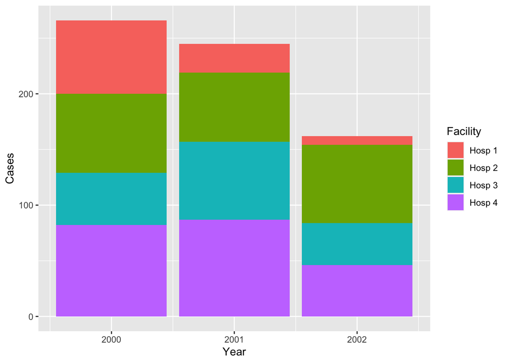

```r
ggplot(df_combined) +
  aes(Year, Cases, fill = Facility) +
  geom_col()
```

But less useful for presenting in a table, so let’s practice converting this long, untidy dataframe into a wider, tidy dataframe:

```r
df_combined %>%
  pivot_wider(
    id_cols = c(Facility, Year, Cases),
    names_from = "Year",
    values_from = "Cases"
  ) %>%
  arrange(Facility) %>%
  janitor::adorn_totals(c("row", "col")) %>%
  knitr::kable() %>%
  kableExtra::row_spec(row = 5, bold = TRUE) %>%
  kableExtra::column_spec(column = 5, bold = TRUE)
```

| Facility | 2000 | 2001 | 2002 | Total |
| --- | --- | --- | --- | --- |
| Hosp 1 | 66 | 26 | 8 | 100 |
| Hosp 2 | 71 | 62 | 70 | 203 |
| Hosp 3 | 47 | 70 | 38 | 155 |
| Hosp 4 | 82 | 87 | 46 | 215 |
| Total | 266 | 245 | 162 | 673 |

N.B. In this case, we had to specify to only include the three variables `Facility`, `Year`, and `Cases` as the additional variable `Measurement` would interfere with the creation of the table:

```r
df_combined %>%
  pivot_wider(
    names_from = "Year",
    values_from = "Cases"
  ) %>%
  knitr::kable()
```

| Measurement | Facility | 2000 | 2001 | 2002 |
| --- | --- | --- | --- | --- |
| 1 | Hosp 4 | 82 | NA | NA |
| 1 | Hosp 3 | 47 | NA | NA |
| 1 | Hosp 2 | 71 | NA | NA |
| 1 | Hosp 1 | 66 | NA | NA |
| 2 | Hosp 4 | NA | 87 | NA |
| 2 | Hosp 3 | NA | 70 | NA |
| 2 | Hosp 2 | NA | 62 | NA |
| 2 | Hosp 1 | NA | 26 | NA |
| 3 | Hosp 4 | NA | NA | 46 |
| 3 | Hosp 3 | NA | NA | 38 |
| 3 | Hosp 2 | NA | NA | 70 |
| 3 | Hosp 1 | NA | NA | 8 |

## Resources

Here is a helpful [tutorial](https://datacarpentry.org/r-socialsci/03-dplyr-tidyr/index.html)